# Day 1 as a Business Analyst: Understanding the Financial Landscape

# 5 Headcount & Labor Cost Analysis

Labor is almost always the largest expense line in a business, often 60 to 70 percent of total OpEx. Understanding who we have, what they cost, and whether we are retaining them is non-negotiable on day one. The headcount data also connects directly back to what we just saw in the budget variance section. Departments that are overspending or understaffed do not exist in isolation — they show up here too.

The table below is the starting point. Before I build any charts I want to see the raw numbers — headcount, salary, tenure, open roles, and attrition — all in one place.

```r
headcount_display <- headcount %>%
  arrange(desc(fully_loaded)) %>%
  mutate(
    avg_salary       = dollar(avg_salary),
    total_labor_cost = dollar(total_labor_cost),
    fully_loaded     = dollar(fully_loaded),
    attrition_rate   = percent(attrition_rate, accuracy = 1)
  )

headcount_display %>%
  kable(
    col.names = c("Department", "Headcount", "Avg Salary",
                  "Avg Tenure (Yrs)", "Open Reqs", "Attrition %",
                  "Total Labor", "Fully Loaded"),
    align = c("l", "r", "r", "r", "r", "r", "r", "r")
  ) %>%
  kable_styling(bootstrap_options = c("striped", "hover", "condensed"),
                full_width = TRUE)
```

| Department | Headcount | Avg Salary | Avg Tenure (Yrs) | Open Reqs | Attrition % | Total Labor | Fully Loaded |
| --- | --- | --- | --- | --- | --- | --- | --- |
| Engineering | 31 | $115,000 | 3.4 | 5 | 12% | $3,565,000 | $4,456,250 |
| Sales | 22 | $82,000 | 2.1 | 3 | 18% | $1,804,000 | $2,255,000 |
| Customer Success | 14 | $68,000 | 2.7 | 2 | 25% | $952,000 | $1,190,000 |
| G&A | 9 | $72,000 | 4.2 | 0 | 8% | $648,000 | $810,000 |
| Marketing | 8 | $78,000 | 1.8 | 1 | 22% | $624,000 | $780,000 |

A few things jump out immediately. Engineering is by far the largest cost center at $4.4 million fully loaded annually and has the most open roles at 5. G&A has the highest average tenure at 4.2 years which makes sense — finance, legal, and HR tend to be stable functions. Customer Success has the lowest average salary at $68,000 and the highest attrition at 25%. That combination is worth pausing on. The people responsible for keeping customers happy are the least compensated and the most likely to leave. The two charts below break this down further.

The first view compares fully loaded labor cost across departments. The second looks at attrition rate with a threshold line at 18% — departments above that line are losing people at a rate that creates real operational risk.

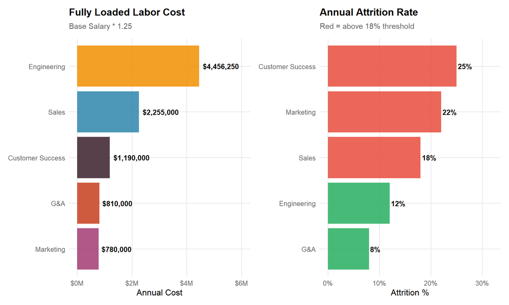

```r
p_hc1 <- headcount %>%
  ggplot(aes(x = reorder(department, fully_loaded),
             y = fully_loaded,
             fill = department)) +
  geom_col(alpha = 0.85) +
  geom_text(aes(label = dollar(fully_loaded)),
            hjust = -0.1, size = 3.5, fontface = "bold") +
  coord_flip() +
  scale_y_continuous(labels = dollar_format(scale = 1e-6, suffix = "M"),
                     limits = c(0, max(headcount$fully_loaded) * 1.35)) +
  scale_fill_manual(values = palette_dept, guide = "none") +
  labs(
    title = "Fully Loaded Labor Cost",
    subtitle = "Base Salary * 1.25",
    x = NULL,
    y = "Annual Cost"
  ) +
  theme_ba()

p_hc2 <- headcount %>%
  ggplot(aes(x = reorder(department, attrition_rate),
             y = attrition_rate,
             fill = attrition_rate >= 0.18)) +
  geom_col(alpha = 0.85) +
  geom_text(aes(label = percent(attrition_rate, accuracy = 1)),
            hjust = -0.1, size = 3.5, fontface = "bold") +
  coord_flip() +
  scale_y_continuous(labels = percent_format(),
                     limits = c(0, 0.32)) +
  scale_fill_manual(values = c("FALSE" = "#27AE60", "TRUE" = "#E74C3C"),
                    guide = "none") +
  labs(
    title = "Annual Attrition Rate",
    subtitle = "Red = above 18% threshold",
    x = NULL,
    y = "Attrition %"
  ) +
  theme_ba()

p_hc1 + p_hc2
```

Engineering dominates the cost chart which is expected given the combination of headcount and salary. What stands out on the attrition chart is that three of five departments are at or above the 18% threshold. That is not a one department problem — it is a company wide retention issue that finance leadership needs to be aware of.

The bar charts show each dimension separately. This next view combines them. The goal is to find departments where high cost and high attrition overlap — because that is where the business is taking the most financial risk. Every person who leaves has to be replaced, and replacement costs typically run 50 to 100 percent of annual salary when you account for recruiting, onboarding, and lost productivity.

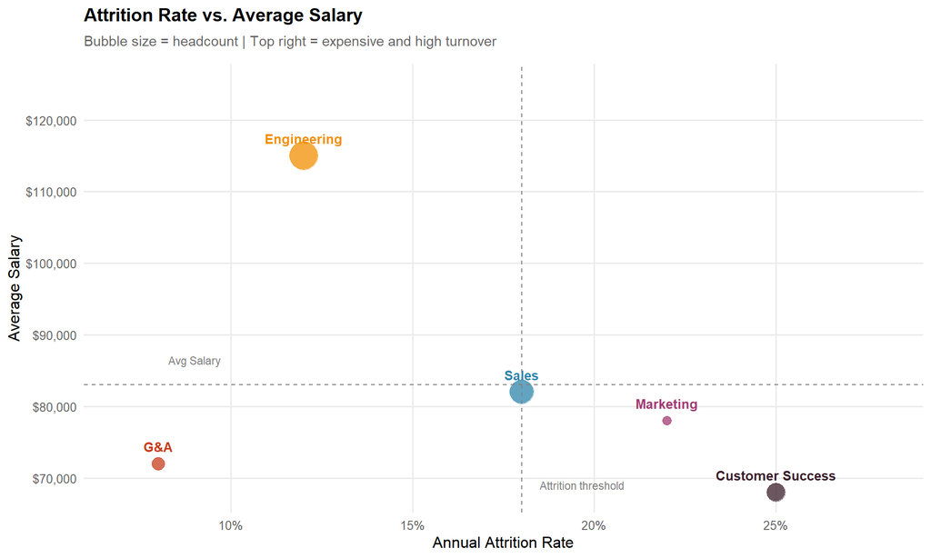

```r
headcount %>%
  ggplot(aes(x = attrition_rate, y = avg_salary,
             size = headcount, color = department, label = department)) +
  geom_point(alpha = 0.75) +
  geom_text(vjust = -1.2, hjust = 0.5, size = 3.5, fontface = "bold") +
  geom_vline(xintercept = 0.18, linetype = "dashed", color = "grey50") +
  geom_hline(yintercept = mean(headcount$avg_salary),
             linetype = "dashed", color = "grey50") +
  annotate("text", x = 0.185, y = 69000,
           label = "Attrition threshold",
           color = "grey50", size = 3, hjust = 0) +
  annotate("text", x = 0.09,
           y = mean(headcount$avg_salary) + 3500,
           label = "Avg Salary",
           color = "grey50", size = 3) +
  scale_x_continuous(labels = percent_format(), limits = c(0.07, .28)) +
  scale_y_continuous(labels = dollar_format(), limits = c(NA, 125000)) +
  scale_color_manual(values = palette_dept, guide = "none") +
  scale_size(range = c(3,10), guide = "none") +
  labs(
    title = "Attrition Rate vs. Average Salary",
    subtitle = "Bubble size = headcount | Top right = expensive and high turnover",
    x = "Annual Attrition Rate",
    y = "Average Salary"
  ) +
  theme_ba()
```

# 6 Unit Economics

This is the section most junior analysts skip. Unit economics live at the intersection of finance, product, and operations and understanding them tells you whether the growth we saw in the revenue section is actually sustainable. A business can grow revenue every month and still be destroying value if it costs more to acquire and serve a customer than that customer is ever going to return. The summary table below gives me a snapshot of where things stand at the end of the period.

```r
latest <- unit_econ %>%
  slice_tail(n = 1)

latest
```

[output not shown]

```r
unit_econ_display <- tibble(
  Metric = c(
    "Total Customers",
    "New Customers (Latest Month)",
    "Churned Customers (Latest Month)",
    "Customer Acquisition Cost",
    "Monthly ARPU",
    "Monthly Churn Rate",
    "Estimated LTV",
    "LTV:CAC Ratio"
  ),
  Value = c(
    comma(latest$total_customers),
    comma(latest$new_customers),
    comma(latest$churned_customers),
    dollar(latest$cac),
    dollar(latest$arpu),
    percent(latest$churn_rate, accuracy = 0.1),
    dollar(latest$ltv),
    round(latest$ltv_cac_ratio, 2)
  ),
  Interpretation = c(
    "Current book of business",
    "Gross new logos this month",
    "Accounts lost this month",
    "Sales and marketing spend per new customer",
    "Average revenue per user per month",
    "Percent of customers lost per month",
    "ARPU divided by churn rate times 70% margin",
    "Target is 3x or above for a healthy business"
  )
)

unit_econ_display %>%
  kable(align = c("l", "r", "l")) %>%
  kable_styling(bootstrap_options = c("striped", "hover"),
                full_width = FALSE)
```

| Metric | Value | Interpretation |
| --- | --- | --- |
| Total Customers | 3,307 | Current book of business |
| New Customers (Latest Month) | 215 | Gross new logos this month |
| Churned Customers (Latest Month) | 84 | Accounts lost this month |
| Customer Acquisition Cost | $676.56 | Sales and marketing spend per new customer |
| Monthly ARPU | $62.86 | Average revenue per user per month |
| Monthly Churn Rate | 2.5% | Percent of customers lost per month |
| Estimated LTV | $1,732.29 | ARPU divided by churn rate times 70% margin |
| LTV:CAC Ratio | 2.56 | Target is 3x or above for a healthy business |

The LTV to CAC ratio at 2.56 is the number that concerns me most. It is below the 3x threshold that most operators treat as the minimum for a healthy acquisition engine. That means for every dollar we spend acquiring a customer we are getting back roughly $2.56 in lifetime value. That is not catastrophic but it is not comfortable either. The three charts below tell me how we got here and where things are heading.

Customer acquisition cost tells me how efficiently the sales and marketing machine is converting spend into new customers. If CAC is rising it means we are working harder and spending more to win the same number of accounts. If it is falling it means we are getting more efficient. The trend over 24 months tells a more honest story than any single month.

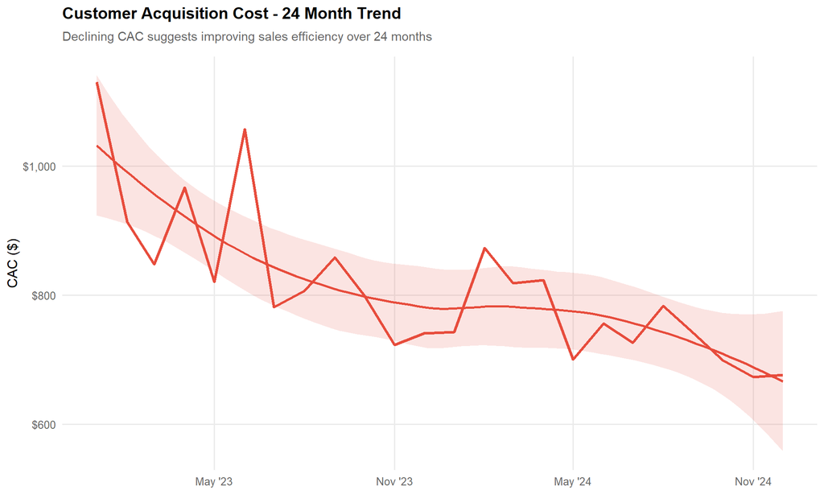

```r
unit_econ %>%
  ggplot(aes(x = month, y = cac)) +
  geom_line(color = "#E74C3C", linewidth = 1.2) +
  geom_smooth(method = "loess", se = TRUE, alpha = 0.15,
              color = "#E74C3C", fill = "#E74C3C") +
  scale_y_continuous(labels = dollar_format()) +
  scale_x_date(date_labels = "%b '%y", date_breaks = "6 months") +
  labs(
    title = "Customer Acquisition Cost - 24 Month Trend",
    subtitle = "Declining CAC suggests improving sales efficiency over 24 months",
    x = NULL,
    y= "CAC ($)"
  ) +
  theme_ba()
```

CAC has been declining over the period which is an encouraging sign. The business is getting more efficient at acquiring customers, likely through improving sales processes, better marketing targeting, or both. The question I would ask is whether this is intentional or whether we are simply picking lower hanging fruit and deferring the harder prospects for later. Declining CAC that is driven by cherry picking easy deals will reverse the moment those deals run out.

CAC declining is good news but it does not tell the full story on its own. What matters is whether the value of a customer over their lifetime justifies what we spent to acquire them. That is the LTV to CAC ratio and it is the single most important unit economics metric for understanding the health of the growth engine.

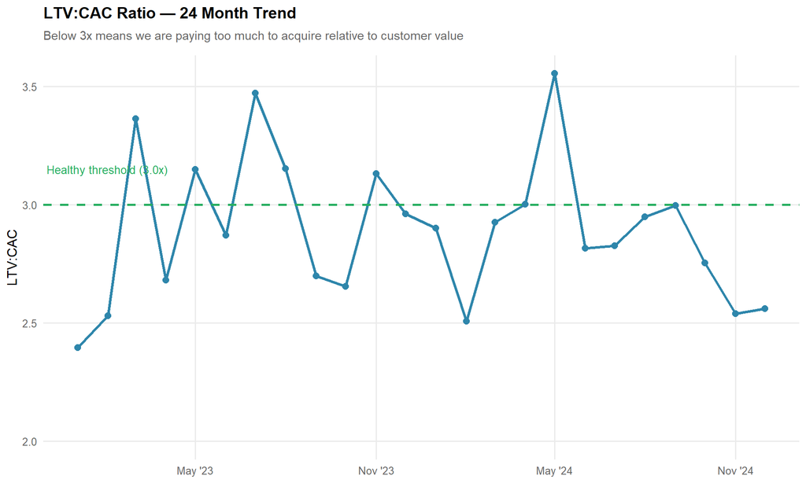

```r
unit_econ %>%
  ggplot(aes(x=month, y = ltv_cac_ratio)) +
  geom_line(color = "#2E86AB", linewidth =1.2) +
  geom_point(color = "#2E86AB", size = 2.5) +
  geom_hline(yintercept = 3, linetype = 'dashed',
             color = "#27ae60", linewidth = 1) +
  annotate("text",
           x = min(unit_econ$month) + 30,
           y = 3.15,
           label = "Healthy threshold (3.0x)",
           color = "#27ae60", size = 3.5) +
  scale_x_date(date_labels = "%b '%y", date_breaks = "6 months") +
  scale_y_continuous(limits = c(2, NA)) +
    labs(
    title    = "LTV:CAC Ratio — 24 Month Trend",
    subtitle = "Below 3x means we are paying too much to acquire relative to customer value",
    x = NULL,
    y = "LTV:CAC"
  ) +
  theme_ba()
```

The last unit economics view is churn. Every percentage point of monthly churn compounds. At 2% monthly you lose roughly 22% of your customer base annually. At 3% that number climbs to 31%. Churn is the leaky bucket underneath all the growth numbers we looked at in section three and it connects directly to the Customer Success attrition problem we flagged in section five. The question is not just where churn is today but where it has been and what direction it is moving.

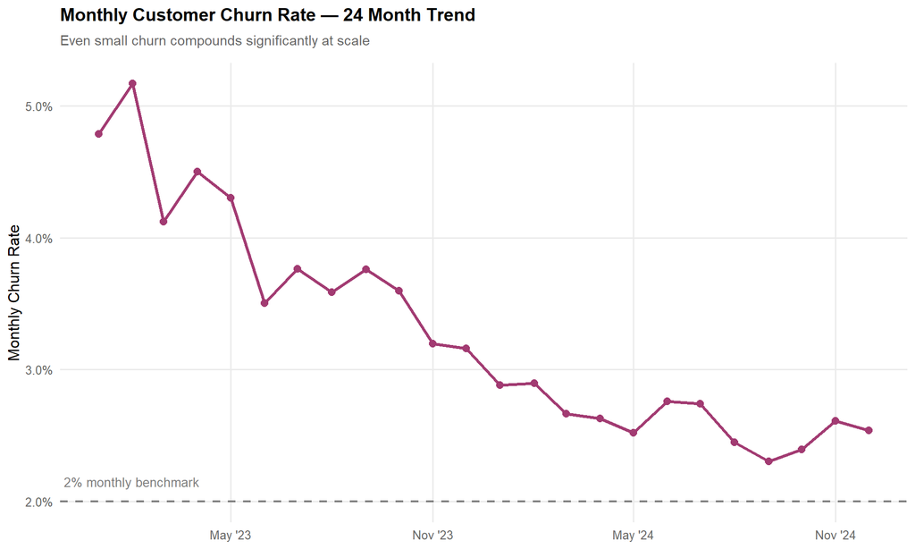

```r
unit_econ %>%
  ggplot(aes(x = month, y = churn_rate)) +
  geom_line(color = "#A23B72", linewidth = 1.2) +
  geom_point(color = "#A23B72", size = 2.5) +
  geom_hline(yintercept = 0.02, linetype = "dashed",
             color = "grey50", linewidth = 0.8) +
  annotate("text",
           x     = min(unit_econ$month) + 30,
           y     = 0.0215,
           label = "2% monthly benchmark",
           color = "grey50", size = 3.5) +
  scale_y_continuous(labels = percent_format(accuracy = 0.1)) +
  scale_x_date(date_labels = "%b '%y", date_breaks = "6 months") +
  labs(
    title    = "Monthly Customer Churn Rate — 24 Month Trend",
    subtitle = "Even small churn compounds significantly at scale",
    x = NULL,
    y = "Monthly Churn Rate"
  ) +
  theme_ba()
```

# 7 Executive Summary

I have now looked at this business through four lenses. Here is what I would walk into my manager’s office to say at the end of day one. Not conclusions, not recommendations — those come after I have had more conversations. But these are the patterns I see, the questions they raise, and the things I want to understand better before I start building anything.

```r
tibble(
  Category = c(
    "Revenue Growth (YoY)",
    "Gross Margin (Latest)",
    "EBITDA Margin (Latest)",
    "Marketing Budget Variance (YTD)",
    "Engineering Budget Variance (YTD)",
    "Customer Success Attrition",
    "LTV:CAC Ratio (Latest)",
    "Monthly Churn Rate (Latest)"
  ),
  Value = c(
    percent(
      (monthly_pl %>% filter(year == 2024) %>% pull(revenue) %>% mean()) /
      (monthly_pl %>% filter(year == 2023) %>% pull(revenue) %>% mean()) - 1,
      accuracy = 0.1),
    percent(last(monthly_pl$gross_margin), accuracy = 0.1),
    percent(last(monthly_pl$ebitda_margin), accuracy = 0.1),
    percent(filter(bva_summary, department == "Marketing") %>%
              pull(variance_pct), accuracy = 0.1),
    percent(filter(bva_summary, department == "Engineering") %>%
              pull(variance_pct), accuracy = 0.1),
    percent(filter(headcount, department == "Customer Success") %>%
              pull(attrition_rate), accuracy = 1),
    as.character(round(last(unit_econ$ltv_cac_ratio), 2)),
    percent(last(unit_econ$churn_rate), accuracy = 0.1)
  ),
Signal = c(
  "Strong",
  "Healthy",
  "Watch",
  "Investigate",
  "Deferred hiring",
  "Investigate",
  "Below threshold",
  "Improving"
)
) %>%
  kable(align = c("l", "r", "c"), escape = FALSE) %>%
  kable_styling(bootstrap_options = c("striped", "hover"),
                full_width = FALSE)
```

| Category | Value | Signal |
| --- | --- | --- |
| Revenue Growth (YoY) | 13.5% | Strong |
| Gross Margin (Latest) | 46.9% | Healthy |
| EBITDA Margin (Latest) | -0.8% | Watch |
| Marketing Budget Variance (YTD) | 13.2% | Investigate |
| Engineering Budget Variance (YTD) | -3.6% | Deferred hiring |
| Customer Success Attrition | 25% | Investigate |
| LTV:CAC Ratio (Latest) | 2.56 | Below threshold |
| Monthly Churn Rate (Latest) | 2.5% | Improving |

**What looks healthy:**

**What I am watching:**

EBITDA margin is thin and has dipped negative in several months. The business is not consistently profitable at the operating level and there is not much cushion if revenue softens or costs spike. Engineering has 5 open roles and is running under budget — that underspend is not savings, it is deferred cost that will hit the moment hiring accelerates.

**What I am flagging for week one conversations:**